# Math-Practical-Major-6th-sem

Problem-3: To solve the following system of ordinary differential equations
$$ \dfrac{dx}{dt} + \dfrac{dy}{dt} -2x -4y = e^t , $$ $$ \dfrac{dx}{dt} + \dfrac{dy}{dt} -y = e^{4t} $$

Solution:

```
Clear[x, y, t,
    systems, solution, paricularSol]

systems = {
    x'[t] + y'[t] - 2 x[t] - 4 y[t] == Exp[t],
    x'[t] + y'[t] - y[t] == Exp[4 t]
}

solution = DSolve[systems, {x, y}, t]

particularSol = {x[t], y[t]} /. solution /. {C[1] -> 2}
Plot[Evaluate[particularSol], {t, -10, 10}]
```

[figure not shown]

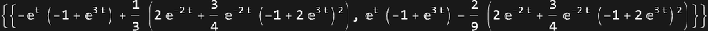

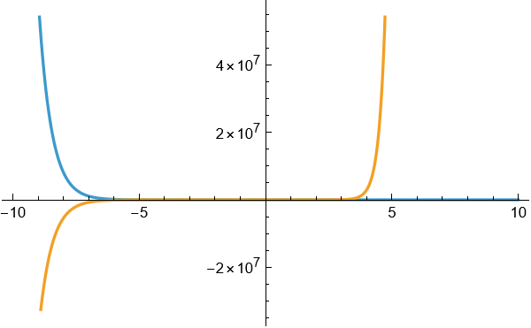

Result: The solution of the given system is obtained in the output and visualized as a graph.

Practical-6

Solution of One-Dimensional Heat equation $ u_t = k\,u_{xx} $ for a homogeneous rod of length $l$

i.e. To solve the IBVP (Initial Boundary Value Problem):
$$ \dfrac{\partial u}{\partial t} = k \dfrac{\partial^2 u}{\partial x^2},\; 0 < x < l,\; t > 0 $$ $$ u(0, t) = 0,\; u(l, t) = 0,\; t \geq 0 $$ $$ u(0, t) = f(x),\; 0 \leq x \leq l $$

Problem-1: To obtain the solution of the heat equation
$$ u_{t} - u_{xx} = 0, \;\; 0 < x < 5,\;\; t > 0 $$ for the initial conditions $$ u(x, 0) = 0,\;\; u(0, t) = \sin{(t)}, \;\; u(5, t) = 0, \;\; 0 \leq x \leq 5,\;\; t \geq 0$$

Solution:

```
Clear[x, t, u, pdeWithConditions, solution]

pdeWithConditions = {D[u[x, t], t] - D[u[x, t], {x, 2}] == 0,
    u[x, 0] == 0,
    u[0, t] == Sin[t],
    u[5, t] == 0
}

solution = NDSolve[pdeWithConditions, u[x, t], {x, 0, 5}, {t, 0, 10},
    PrecisionGoal -> 3
]

Plot3D[u[x, t] /. solution, {x, 0, 5}, {t, 0, 4},
    AxesLabel -> {"x", "t", "u"},
    PlotLabel -> "Solution surface of the given Heat equation",
    ColorFunction -> (ColorData["TemperatureMap"][#3] &),
    ColorFunctionScaling -> False
]
```

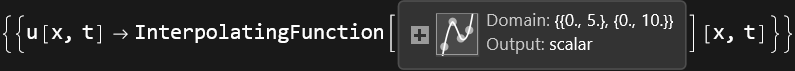

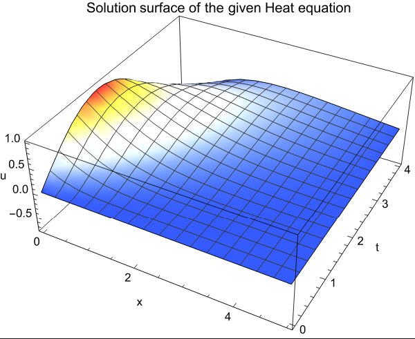

Result: The solution of the given Heat equation is obtained and visualized as a surface.

Problem-2: To obtain the solution of the heat equation
$$ u_{t} - u_{xx} = 0, \;\; 0 < x < 10,\;\; t > 0 $$ for the initial conditions $$ u(x, 0) = \tanh{(x)} ,\;\; u(0, t) = t, \;\; u(10, t) = 0, \;\; 0 \leq x \leq 10,\;\; t \geq 0$$

Solution:

```
Clear[x, t, u, pdeWithConditions, solution]

pdeWithConditions = {D[u[x, t], t] - D[u[x, t], {x, 2}] == 0,
    u[x, 0] == Tanh[x],
    u[0, t] == t,
    u[10, t] == 0
}

solution = NDSolve[pdeWithConditions, u[x, t], {x, 0, 10}, {t, 0, 10},
    PrecisionGoal -> 3
]

Plot3D[u[x, t] /. solution, {x, 0, 10}, {t, 0, 4},
    AxesLabel -> {"x", "t", "u"},
    PlotLabel -> "Solution surface of the given Heat equation",
    ColorFunction -> (ColorData["TemperatureMap"][#3] &),
    ColorFunctionScaling -> True
]
```

```
NDSolve::ibcinc: Warning: boundary and initial conditions are inconsistent.
```

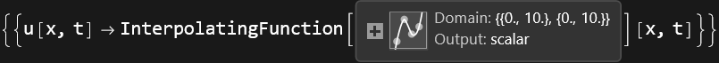

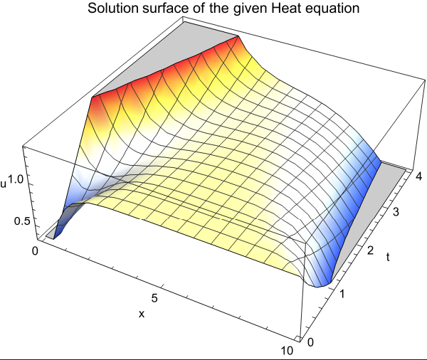

Result: The solution of the given Heat equation is obtained and visualized as a surface.

Problem-3: To obtain the solution of the heat equation
$$ u_{t} - u_{xx} = 0, \;\; 0 < x < 5,\;\; t > 0 $$ for the initial conditions $$ u(x, 0) = \sin{(x)} ,\;\; u(0, t) = 1, \;\; u(5, t) = 0, \;\; 0 \leq x \leq 5,\;\; t \geq 0 $$

Solution:

```
Clear[x, t, u, pdeWithConditions, solution]

pdeWithConditions = {D[u[x, t], t] - D[u[x, t], {x, 2}] == 0,
    u[x, 0] == Sin[x],
    u[0, t] == 1,
    u[5, t] == 0
}

solution = NDSolve[pdeWithConditions, u[x, t], {x, 0, 5}, {t, 0, 4},
    PrecisionGoal -> 3
]

Plot3D[u[x, t] /. solution, {x, 0, 5}, {t, 0, 4},
    AxesLabel -> {"x", "t", "u"},
    PlotLabel -> "Solution surface of the given Heat equation",
    ColorFunction -> (ColorData["TemperatureMap"][#3] &),
    ColorFunctionScaling -> False
]
```

```
NDSolve::ibcinc: Warning: boundary and initial conditions are inconsistent.
```

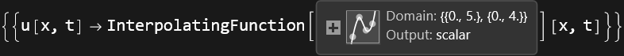

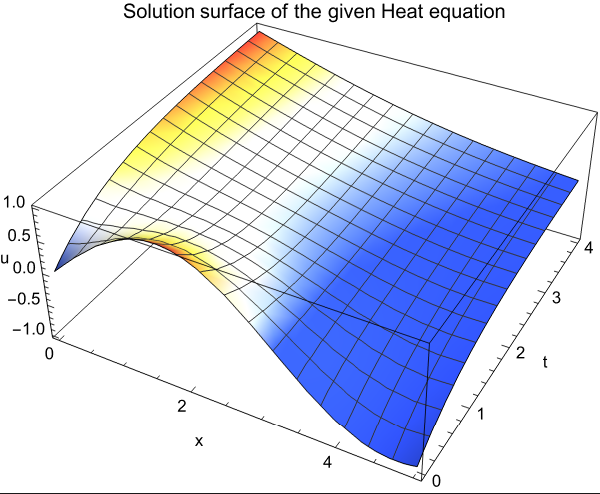

Result: The solution of the given Heat equation is obtained and visualized as a surface.